# Associat’em all

Andrew Lee

# Overview

Pokémon Go is an AR mobile game developed by the result of a collaboration between Niantic, Nintendo, and The Pokémon Company. It uses the mobile device GPS to locate, capture, battle, and train Pokémon, which appear as if they are in the player’s real-world location. In this game, it has been well known to players that some Pokémon appears together. So, in this project, I am going to describe Pokémon’s occurrences using the association rules.

In a nutshell, the association rule summarises data as “what goes with what.” For example, in the Pokémon Go, a player may want to know which Pokémon appears with which Pokémon. In this case, the player can build association rules to see the most common rules of Pokémon occurrences. This method is also called *market basket analysis*, since it was originated from the consumer transaction databases to see dependencies between purchases of different items and build the recommendation systems.

# Dataset

- **pokemonId:** the identifier of a pokemon. (integer; ranges between 1 and 151, contains only Kanto pokemons)
- **cooc_1 ~ cooc_151:** co-occurrence with any other pokemon (pokemon ids range between 1 and 151) within 100m distance (factor; levels with “true” and “false”)

# Data Preprocessing

```r
dim(raw.data)
```

```
## [1] 296021    152
```

```r
head(raw.data[,1:17], 6)
```

```
##   pokemonId cooc_1 cooc_2 cooc_3 cooc_4 cooc_5 cooc_6 cooc_7 cooc_8 cooc_9
## 1        16   true  false  false  false  false  false  false  false  false
## 2       133  false  false  false  false  false  false  false  false  false
## 3        16  false  false  false  false  false  false  false  false  false
## 4        13  false  false  false  false  false  false  false  false  false
## 5       133  false  false  false  false  false  false  false  false  false
## 6        21  false  false  false  false  false  false  false  false  false
##   cooc_10 cooc_11 cooc_12 cooc_13 cooc_14 cooc_15 cooc_16
## 1   false   false   false   false   false   false   false
## 2   false   false   false    true   false   false   false
## 3   false   false   false    true   false   false   false
## 4   false   false   false   false   false   false   false
## 5   false   false   false   false   false   false   false
## 6   false   false   false   false   false   false   false
```

Before building the rules, we need to format the raw data into “transactions”. We observe that the first column represents the Pokémon appeared, and the rest of 151 columns represent the other Pokémon appeared with. So, I created an empty matrix, ‘pokemonID’, initially filled with all FALSE. Then, for each row in the matrix, changed the value to TRUE when the column matches the pokemonId from the raw data.

```r
ID = raw.data[,1]
pokemonID = matrix(FALSE, nrow = 296021, ncol = 151)

for(i in 1:296021){
  pokemonID[i,ID[i]] = TRUE
}
```

Since all the other columns in the raw data are stored as factor with level “false” and “true”, I also changed the matrix values into boolean.

```r
Boolean = function(x){
  levels(x) = c(FALSE, TRUE)
  x = as.logical(x)
}

raw.data= raw.data[,2:152]
raw.data = apply(raw.data, 2, Boolean)
```

```r
head(raw.data[,1:17], 6)
```

```
##      cooc_1 cooc_2 cooc_3 cooc_4 cooc_5 cooc_6 cooc_7 cooc_8 cooc_9
## [1,]   TRUE  FALSE  FALSE  FALSE  FALSE  FALSE  FALSE  FALSE  FALSE
## [2,]  FALSE  FALSE  FALSE  FALSE  FALSE  FALSE  FALSE  FALSE  FALSE
## [3,]  FALSE  FALSE  FALSE  FALSE  FALSE  FALSE  FALSE  FALSE  FALSE
## [4,]  FALSE  FALSE  FALSE  FALSE  FALSE  FALSE  FALSE  FALSE  FALSE
## [5,]  FALSE  FALSE  FALSE  FALSE  FALSE  FALSE  FALSE  FALSE  FALSE
## [6,]  FALSE  FALSE  FALSE  FALSE  FALSE  FALSE  FALSE  FALSE  FALSE
##      cooc_10 cooc_11 cooc_12 cooc_13 cooc_14 cooc_15 cooc_16 cooc_17
## [1,]   FALSE   FALSE   FALSE   FALSE   FALSE   FALSE   FALSE   FALSE
## [2,]   FALSE   FALSE   FALSE    TRUE   FALSE   FALSE   FALSE   FALSE
## [3,]   FALSE   FALSE   FALSE    TRUE   FALSE   FALSE   FALSE   FALSE
## [4,]   FALSE   FALSE   FALSE   FALSE   FALSE   FALSE   FALSE   FALSE
## [5,]   FALSE   FALSE   FALSE   FALSE   FALSE   FALSE   FALSE   FALSE
## [6,]   FALSE   FALSE   FALSE   FALSE   FALSE   FALSE   FALSE   FALSE
```

Then, combined the two matrix and change the name of the each columns as the name of the Pokémon it represents.

```r
occurance.data = raw.data
occurance.data[,-1] = ((raw.data[,-1] + pokemonID[,-1]) > 0) + 0

colnames(occurance.data) = pokedex[,2]
head(occurance.data[,1:17], 6)
```

```
##      bulbasaur ivysaur venusaur charmander charmeleon charizard squirtle
## [1,]         1       0        0          0          0         0        0
## [2,]         0       0        0          0          0         0        0
## [3,]         0       0        0          0          0         0        0
## [4,]         0       0        0          0          0         0        0
## [5,]         0       0        0          0          0         0        0
## [6,]         0       0        0          0          0         0        0
##      wartortle blastoise caterpie metapod butterfree weedle kakuna
## [1,]         0         0        0       0          0      0      0
## [2,]         0         0        0       0          0      1      0
## [3,]         0         0        0       0          0      1      0
## [4,]         0         0        0       0          0      1      0
## [5,]         0         0        0       0          0      0      0
## [6,]         0         0        0       0          0      0      0
##      beedrill pidgey pidgeotto
## [1,]        0      1         0
## [2,]        0      0         0
## [3,]        0      1         0
## [4,]        0      0         0
## [5,]        0      0         0
## [6,]        0      0         0
```

As we see above, we got a binary matrix in which columns are Pokémon, rows again represent occurrence, and each cell has either a 1 or 0, indicating the presence or absence of a Pokémon in the Pokémon occurrence. For example, the first row in the matrix above indicates that the Bulbasaur co-occurred with Pidgey within 100m distance.

Finally, change the matrix into the transaction list format as below. Each of the rows in the list below is called “item sets.” The idea behind the association rule is to examine all the possible rules between items (Pokémon in this project) in an if-then format and select only those indicating some dependencies between the items. We call the “if” part as *antecedent item* and “then” part as *consequent item*. The antecedent and consequent items consist item sets. For example, in the 8th row below, the antecedent is *Sandshrew* and the consequent is *Nidoran (male)*. Another possible rule we can see below is “If Machop and Tauros, Then Magikarp.” Here the antecednet includes the item set {machop, tauros} and the consequent is {magikarp}.

```r
poke.association = as(occurance.data, "transactions")
inspect(head(poke.association, 10))
```

```
##      items
## [1]  {bulbasaur,pidgey,rattata,nidoran-m}
## [2]  {weedle,rattata,nidoran-m,paras,exeggcute,eevee}
## [3]  {weedle,pidgey,nidoran-m,tauros}
## [4]  {weedle}
## [5]  {eevee}
## [6]  {spearow}
## [7]  {machop,tauros,magikarp}
## [8]  {sandshrew,nidoran-m}
## [9]  {nidoran-m,clefairy,zubat,drowzee,tauros,eevee}
## [10] {rattata}
```

The *support* of the association rule is the number of Pokémon that include both the antecedent and consequent item sets. It can be calculated by the percentage of the total number of records in the data set. In addition to support, *confidence* compares the co-occurence of the antecedent and consequent item sets in the data set to the occurence of the antecedent item sets.

$\displaystyle \ Confidence = \frac{Number \ of \ item \ sets \ with \ both \ antecedent \ and \ consequent \ items}{Number \ of \ item \ sets \ with \ antecedent \ item \ set}$

Meanwhile, if the antecedent and consequent item sets are independent,

$\displaystyle \frac{Number \ of \ item \ sets \ with \ both \ antecedent \ and \ consequent \ items}{Number \ of \ item \ sets \ with \ antecedent \ item \ set} = \frac{P(antecedent) * P(consequent)}{P(antecedent)} = P(consequent)$

By comparing the confidence of the rule with the $\ P(consequent)$ (the number of records with the consequent item divided by the number of entire records), we can calculate *lift ratio*. Lift ratio greater than 1 means that there are some dependencies between the antecedent and consequent items.

While there are several other algorithms, I used *Apriori algorithm* of Agrawal et al. The key idea of the algorithm is to begin with generating frequent item sets with just one item (one-item sets) and to recursively generate frequent item sets with two items, then with three items, and so on. Conduct this process until frequent item sets of all sizes are generated.

For the one-item sets, all we need to do is just counting. For each Pokémon, count how many occurance in the data set include the Pokémon. These counts are the supports for the one-item sets. Then drop one-item sets which have support lower than the minimum, all the other one-item sets will consist a list of the frequent one-item sets. As we see below, the most frequent “item” (Pokémon) is Pidgey followed by Rattata and male Nidoran (in the kanto pokedex, only Nidoran has sex).

[figure not shown]

```r
itemFrequencyPlot(poke.association, topN=20, type='absolute')
```

To generate frequent two-item sets, we use the list of frequent one-item sets. This is because if a certain one-item set did not exceed the minimum support, any larger size item set that include the one-item set will not exceed the minimum support. To generate *k* item sets uses the frequent *k*-1 item sets that were generated in the preceding step. Each step requires a single run through the data set, and therefore the Apriori algorithm is very fast even for a large number of unique items in the dataset.

```r
pokemon.rules = apriori(poke.association, parameter = list(support = 0.01, confidence = 0.5))
```

```
## Apriori
##
## Parameter specification:
##  confidence minval smax arem  aval originalSupport maxtime support minlen
##         0.5    0.1    1 none FALSE            TRUE       5    0.01      1
##  maxlen target   ext
##      10  rules FALSE
##
## Algorithmic control:
##  filter tree heap memopt load sort verbose
##     0.1 TRUE TRUE  FALSE TRUE    2    TRUE
##
## Absolute minimum support count: 2960
##
## set item appearances ...[0 item(s)] done [0.00s].
## set transactions ...[144 item(s), 296021 transaction(s)] done [0.05s].
## sorting and recoding items ... [40 item(s)] done [0.01s].
## creating transaction tree ... done [0.12s].
## checking subsets of size 1 2 3 4 done [0.01s].
## writing ... [43 rule(s)] done [0.00s].
## creating S4 object  ... done [0.03s].
```

```r
pokemon.rules = sort(pokemon.rules, by='confidence', decreasing = TRUE)
summary(pokemon.rules)
```

```
## set of 43 rules
##
## rule length distribution (lhs + rhs):sizes
##  2  3  4
##  5 37  1
##
##    Min. 1st Qu.  Median    Mean 3rd Qu.    Max.
##   2.000   3.000   3.000   2.907   3.000   4.000
##
## summary of quality measures:
##     support          confidence          lift           count
##  Min.   :0.01025   Min.   :0.5015   Min.   :1.653   Min.   :3034
##  1st Qu.:0.01175   1st Qu.:0.5324   1st Qu.:1.857   1st Qu.:3480
##  Median :0.01353   Median :0.5594   Median :2.563   Median :4005
##  Mean   :0.01536   Mean   :0.5752   Mean   :2.956   Mean   :4548
##  3rd Qu.:0.01674   3rd Qu.:0.6056   3rd Qu.:3.353   3rd Qu.:4954
##  Max.   :0.03245   Max.   :0.7225   Max.   :6.816   Max.   :9605
##
## mining info:
##              data ntransactions support confidence
##  poke.association        296021    0.01        0.5
```

```r
inspect(pokemon.rules[1:10])
```

```
##      lhs                           rhs         support    confidence
## [1]  {weedle,rattata,nidoran-m} => {pidgey}    0.01140797 0.7225075
## [2]  {pidgey,paras}             => {nidoran-m} 0.01352945 0.6956748
## [3]  {pidgey,zubat}             => {nidoran-m} 0.01562051 0.6923192
## [4]  {weedle,venonat}           => {nidoran-m} 0.01165796 0.6884101
## [5]  {pidgey,venonat}           => {nidoran-m} 0.01825546 0.6716381
## [6]  {zubat,drowzee}            => {nidoran-m} 0.01229980 0.6600798
## [7]  {rattata,venonat}          => {nidoran-m} 0.01376254 0.6549839
## [8]  {weedle,venonat}           => {pidgey}    0.01089450 0.6433273
## [9]  {rattata,eevee}            => {pidgey}    0.01396523 0.6194186
## [10] {rattata,venonat}          => {pidgey}    0.01296530 0.6170418
##      lift     count
## [1]  2.335926 3377
## [2]  3.547962 4005
## [3]  3.530848 4624
## [4]  3.510912 3451
## [5]  3.425374 5404
## [6]  3.366426 3641
## [7]  3.340437 4074
## [8]  2.079930 3225
## [9]  2.002631 4134
## [10] 1.994947 3838
```

We see that when Weedle, Rattata, Nidoran appeared in a region, it is highly likely to see Pidgey within 100m.

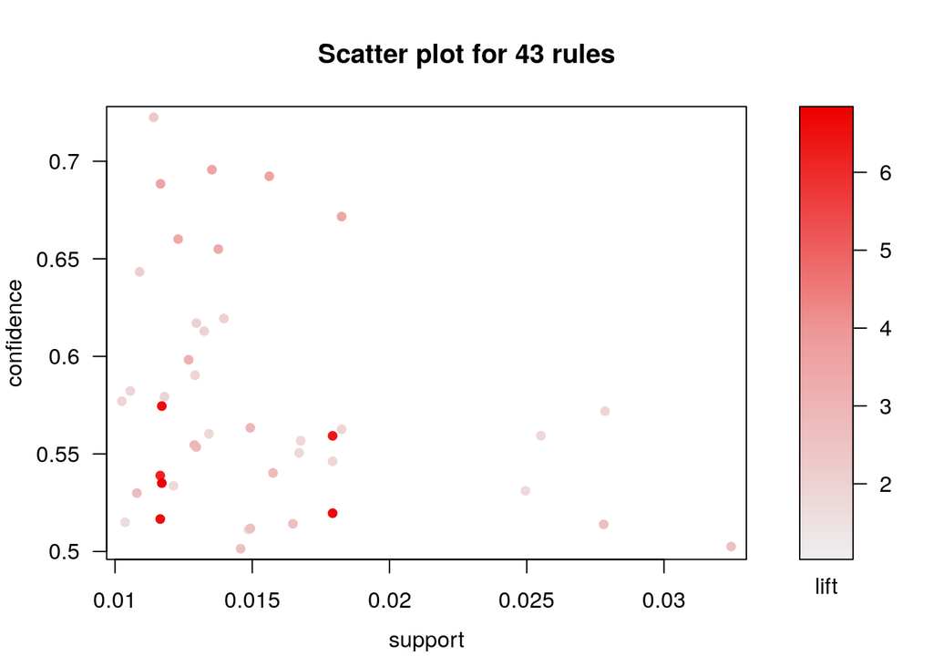

```r
plot(pokemon.rules)
```

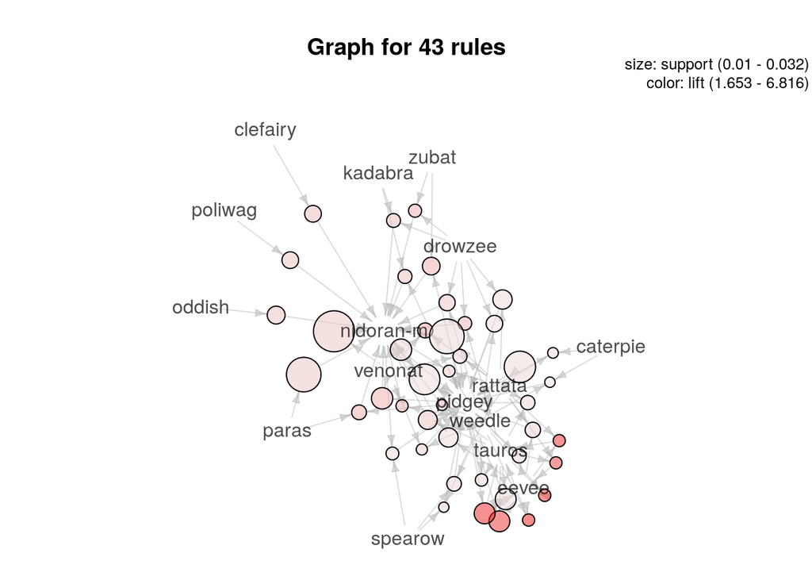

```r
plot(pokemon.rules, method="graph")
```

Size of the circle means support and the color means lift. You can find the project files in the link below.

https://github.com/aleedk1123/rpokemongo